# Predicting responses with virtual evidence

Derek Powell

```r
net.struct <- readRDS("net-struct-cogsci2018.rds")
source("../study1/vacc_import_data.R")
```

[output not shown]

```r
source("../Scripts/gmod_tools.R")
source("../Scripts/virtualEvidence.R")
library(rjags)
```

# Predicting responses

This notebook aims to examine/address the issue of predicting out-of-sample data using our model. In a previous notebook, `vacc_manyBelief_study3_modelsim.RMD`, I predicted average scale responses from study 3 using the previously learned model by conditioning on the Disease Severe node.

Goals of this notebook are to:

1. Explicitly model the intervention, rather than just conditioning disease severe
2. Use “virtual evidence” to better model individual participants’ responses at time 2.

Most of the heavy lifting is done in `Scripts/virtualEvidence.R`.

```r
# first, re-arrange data
test_retest_df <- d_scored %>%
  filter(condition == "noInterv") %>%
  unite(full_varname, scale, phase) %>%
  mutate(full_varname = gsub("_post","", full_varname)) %>%
  group_by(workerId) %>%
  spread(full_varname, Mean) %>%
  ungroup() %>%
  select(-workerId, -condition)
interv_df <- d_scored %>%
              filter(condition=="diseaseRisk") %>%
              mutate(interv = ifelse(phase=="pre",0,1)) %>%
              group_by(workerId) %>%
              spread(scale, Mean)
# the observed data to predict
data_to_predict <- d_scored %>%
  # filter(condition == "diseaseRisk") %>%
  unite(full_varname, scale, phase) %>%
  mutate(full_varname = gsub("_post","", full_varname)) %>%
  group_by(workerId) %>%
  spread(full_varname, Mean) %>%
  ungroup() %>%
  mutate(interv = ifelse(condition == "diseaseRisk", 1, 0)) %>%
  select(-workerId, -condition)
```

I need to come back to this and organize things a bit better. There are a few different ways I could set up the individual-level predictions.

1. Predicting from “interv”
2. Predicting from observed diseaseSevere

And for each could try to predict either diseaseRisk or both diseaseRisk and noIntervention conditions.

```r
set.seed(12345)
# then make jags model
model <- write_jags_model(bnlearn_to_df(net.struct), d_bn, ve_df = test_retest_df, ve_suffix = "_pre")
```

[output not shown]

```r
interv_fit <- glm(interv ~ diseaseSevere,
                  data = interv_df,
                  family = "binomial"
                  )
model <- add_node(model, glm_to_jags_eq(interv_fit))
```

```
the condition has length > 1 and only the first element will be used
```

```r
# # beta regression stuff

# set.seed(12345)
#
# # then make jags model
# d_bn_beta <- d_bn %>% mutate_all(rescale_beta, lower = -3, upper = 3)
# test_retest_df_beta <- test_retest_df %>% mutate_all(rescale_beta, lower = -3, upper = 3)
# data_to_predict <- data_to_predict %>% mutate_at(vars(-interv), rescale_beta, lower = -3, upper = 3)
#
# model <- write_jags_model(bnlearn_to_df(net.struct), d_bn_beta, family = "beta", ve_df = test_retest_df_beta, ve_suffix = "_pre")
#
# interv_fit <- glm(interv ~ diseaseSevere,
#                   data = interv_df,
#                   family = "binomial"
#                   )
#
# model <- add_node(model, glm_to_jags_eq(interv_fit))
```

## predicting from intervention

```r
nodes_to_predict <- bnlearn::nodes(net.struct) # predict all 14 beliefs
# then do predictions
preds_interv <- make_predictions(model, data_to_predict, nodes_to_predict, iter = 1e4)
preds_interv0 <- make_predictions(model, data_to_predict, nodes_to_predict, c("interv"), iter = 1e4)
```

```r
nodes <- bnlearn::nodes
mae_pred0 <- calc_MAE(data_to_predict, preds_interv0)[nodes(net.struct)]
mae_pred1 <- calc_MAE(data_to_predict, preds_interv)[nodes(net.struct)]
rmse_pred0 <- calc_RMSE(data_to_predict, preds_interv0)[nodes(net.struct)]
rmse_pred1 <- calc_RMSE(data_to_predict, preds_interv)[nodes(net.struct)]
mae_diff <- mae_pred1 - mae_pred0
rmse_diff <- rmse_pred1 - rmse_pred0
```

### Predicting posttest scores

As expected, the model does very well predicting posttest scores. However, this is essentially due entirely to having the pretest score info (possibly model structure is helping too though). In any case, intervention is not having an appreciable effect.

| scale | cor |
| --- | --- |
| diseaseRare | 0.7037697 |
| diseaseSevere | 0.7497706 |
| hb | 0.8404482 |
| infantImmLimCap | 0.7143340 |
| infantImmWeak | 0.7384378 |
| medSkept | 0.8683192 |
| nat | 0.8588857 |
| overpar | 0.7066770 |
| parentExpert | 0.8671338 |
| vaccDanger | 0.9230108 |

[output cut: 5 more lines]

#### Posttest Residuals

In the plot below you can see some kinda nasty looking residuals for hb and overpar. Though the correlation is strong, the residuals are large. There’s just pretty poor prediction for those scales. For some reason the predicted values are falling within a restricted range.

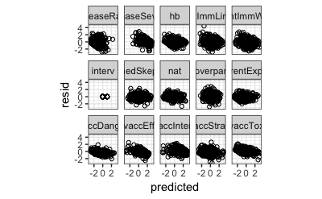

```r
predicted_results_interv %>%
  mutate(resid = observed - predicted) %>%
  filter(!grepl("_pre", scale)) %>%
  ggplot(aes(x = predicted, y = resid)) +
  geom_point(shape=1) +
  facet_wrap(~scale, ncol=5) +
  theme_bw() +
  theme(aspect.ratio=1)
```

### Predicting Change Scores

Here I examined the relationship between predicted and observed change scores. However, there’s a pretty serious flaw in the logic here, because the predicted change scores are computed, in part, from the observed pretest scores.

So what I’m really comparing is:

$obs(post) - obs(pre) = predicted(post) - obs(pre)$

So it’s that same classic problem again.

```r
pred_changes_interv <- predicted_results_interv %>%
  mutate(
    phase = ifelse(grepl("_pre", scale), "pre", "post"),
    scale = gsub("_pre","", scale)
  ) %>%
  gather(type, value, observed,predicted) %>%
  spread(phase, value) %>%
  mutate(change = post - pre) %>%
  select(-post, -pre) %>%
  spread(type, change) %>%
  # group_by(scale) %>%
  # summarize(obs_mean = mean(observed),
  #           pred_mean = mean(predicted)) %>%
  filter( scale != "interv")

pred_changes_interv %>%
  ggplot(aes(x=predicted, y = observed)) +
  geom_point(shape=1) +
  geom_smooth(method = "lm") +
  theme_bw() +
  theme(aspect.ratio=1) +
  facet_wrap(~ scale, ncol = 5) +
  labs(title = "change scores")

pred_changes_interv %>%
  group_by(scale) %>%
  summarize(cor = cor(observed, predicted)) %>%
  bind_rows(tibble(scale="Overall Average", cor = mean(.$cor)))
```

[output not shown]

#### Change score residuals

```r
pred_changes_interv %>%
  mutate(resid = observed - predicted) %>%
  filter(!grepl("_pre",scale)) %>%
  group_by(scale) %>%
  summarize(mean_resid = mean(resid))

pred_changes_interv %>%
  mutate(resid = observed - predicted) %>%
  filter(!grepl("_pre",scale)) %>%
  ggplot(aes(x = predicted, y = resid)) +
  geom_point(shape=1) +
  facet_wrap(~ scale, ncol=5) +
  theme_bw() +
  theme(aspect.ratio = 1)
```

[output not shown]

## Predicting from observed Disease Risk

```r
data_to_predict <- d_scored %>%
  filter(condition == "diseaseRisk") %>%
  unite(full_varname, scale, phase) %>%
  mutate(full_varname = gsub("_post","", full_varname)) %>%
  group_by(workerId) %>%
  spread(full_varname, Mean) %>%
  ungroup() %>%
  mutate(interv = ifelse(condition == "diseaseRisk", 1, 0)) %>%
  select(-workerId, -condition)

preds_dr <- make_predictions(model,
                             data_to_predict,
                             nodes_to_predict[which(nodes_to_predict!="diseaseSevere")])

preds_dr0 <- make_predictions(model,
                             data_to_predict,
                             nodes_to_predict,
                             nodes_held_out = c("interv", "diseaseSevere"))
```

### posttest scores …

with disease risk info …

```r
predicted_results_dr <- data_to_predict %>%
  mutate(
    obs_id = row_number(),
    type = "observed"
    ) %>%
  bind_rows(preds_dr %>%
              mutate(
                obs_id = row_number(),
                type="predicted") %>%
              mutate_at(vars(-type, -obs_id), truncate_to_range, upper = 3, lower = -3)
            ) %>%
  gather(scale, Value, -type, -obs_id) %>%
  spread(type, Value)

predicted_results_dr %>%
  filter(!grepl("_pre", scale),
         scale != "interv") %>%
  ggplot(aes(x=predicted, y = observed)) +
  geom_point(shape=1) +
  facet_wrap(~ scale, ncol = 5) +
  theme_bw() +
  theme(aspect.ratio = 1)

predicted_results_dr %>%
          filter(!grepl("_pre", scale),
          scale != "interv",
          scale != "diseaseSevere") %>%
          group_by(scale) %>%
          summarise(cor = cor(predicted, observed))  %>%
          bind_rows(tibble(scale="Overall Average", cor = mean(.$cor)))
```

[output not shown]

without disease risk info …

```r
predicted_results_dr0 <- data_to_predict %>%
  mutate(
    obs_id = row_number(),
    type = "observed"
    ) %>%
  bind_rows(preds_dr0 %>%
              mutate(
                obs_id = row_number(),
                type="predicted") %>%
              mutate_at(vars(-type, -obs_id), truncate_to_range, upper = 3, lower = -3)
            ) %>%
  gather(scale, Value, -type, -obs_id) %>%
  spread(type, Value)

predicted_results_dr0 %>%
  filter(!grepl("_pre", scale),
         scale != "interv") %>%
  ggplot(aes(x=predicted, y = observed)) +
  geom_point(shape=1) +
  facet_wrap(~ scale, ncol = 5) +
  theme_bw() +
  theme(aspect.ratio = 1)

predicted_results_dr0 %>%
          filter(!grepl("_pre", scale),
          scale != "interv") %>%
          group_by(scale) %>%
          summarise(cor = cor(predicted, observed))  %>%
  bind_rows(tibble(scale="Overall Average", cor = mean(.$cor)))
```

Comparing fits …

```r
f0 <- calc_RMSE(true_data = data_to_predict[,nodes_to_predict[which(nodes_to_predict!="diseaseSevere")]],
         predictions = preds_dr0[,nodes_to_predict[which(nodes_to_predict!="diseaseSevere")]])

f1 <- calc_RMSE(true_data = data_to_predict[,nodes_to_predict[which(nodes_to_predict!="diseaseSevere")]],
         predictions = preds_dr[,nodes_to_predict[which(nodes_to_predict!="diseaseSevere")]])

mean(f1) - mean(f0)
```

[output not shown]

### change scores …

THESE AREN’T A GOOD WAY TO LOOK AT THIS!! with diseaseSeverity info

```r
pred_changes_dr <- predicted_results_dr %>%
  mutate(
    phase = ifelse(grepl("_pre", scale), "pre", "post"),
    scale = gsub("_pre","", scale)
  ) %>%
  gather(type, value, observed, predicted) %>%
  spread(phase, value) %>%
  mutate(change = post - pre) %>%
  select(-post, -pre) %>%
  spread(type, change) %>%
  # group_by(scale) %>%
  # summarize(obs_mean = mean(observed),
  #           pred_mean = mean(predicted)) %>%
  filter( scale != "interv",
          scale != "diseaseSevere")

pred_changes_dr %>%
  ggplot(aes(x=predicted, y = observed)) +
  geom_point(shape=1) +
  geom_smooth(method = "lm") +
  facet_wrap(~ scale, ncol = 5) +
  theme_bw() +
  theme(aspect.ratio = 1)

pred_changes_dr %>%
  group_by(scale) %>%
  summarize(cor = cor(observed, predicted)) %>%
  bind_rows(tibble(scale="Overall Average", cor = mean(.$cor)))
```

without disease severity info …

```r
pred_changes_dr0 <- predicted_results_dr0 %>%
  mutate(
    phase = ifelse(grepl("_pre", scale), "pre", "post"),
    scale = gsub("_pre","", scale)
  ) %>%
  gather(type, value, observed, predicted) %>%
  spread(phase, value) %>%
  mutate(change = post - pre) %>%
  select(-post, -pre) %>%
  spread(type, change) %>%
  # group_by(scale) %>%
  # summarize(obs_mean = mean(observed),
  #           pred_mean = mean(predicted)) %>%
  filter( scale != "interv",
          scale != "diseaseSevere")

pred_changes_dr0 %>%
  ggplot(aes(x=predicted, y = observed)) +
  geom_point(shape=1) +
  geom_smooth(method = "lm") +
  facet_wrap(~ scale, ncol = 5) +
  theme_bw() +
  theme(aspect.ratio = 1)

pred_changes_dr0 %>%
  group_by(scale) %>%
  summarize(cor = cor(observed, predicted)) %>%
  bind_rows(tibble(scale="Overall Average", cor = mean(.$cor)))
```

# Model comparison conclusions

So we’re basically right back where we started, with a model that does not meaningfully predict attitude change at the individual level.

# another attempt at predicting change scores …

Here I’m predicting change scores by predicting all nodes based on pretest disease severity and posttest disease severerity and taking the difference. This is basically analogous to what I did the very first time I tried to predict this, but with the “regularizing” effect of pretest measures, which seems to be making htings even worse.

Keeping this here in case it’s salvageable.

```r
preds_ds_pre <- make_predictions(model,
                             data_to_predict %>% mutate(diseaseSevere = diseaseSevere_pre),
                             nodes_to_predict[which(nodes_to_predict!="diseaseSevere")])

preds_ds_post <- make_predictions(model,
                             data_to_predict,
                             nodes_to_predict[which(nodes_to_predict!="diseaseSevere")])

preds_ds_change <- preds_ds_post - preds_ds_pre
```

```r
change_preds2 <- data_to_predict %>%
  mutate(
    obs_id = row_number(),
    type = "observed"
    ) %>%
  gather(scale, value, -obs_id, -type) %>%
  mutate(
    phase = ifelse(grepl("_pre", scale), "pre", "post"),
    scale = gsub("_pre","", scale)
  ) %>%
  spread(phase, value) %>%
  mutate(change = post - pre) %>%
  select(-post,-pre) %>%
  spread(scale, change) %>%
  bind_rows(
    preds_ds_change %>%
      mutate(obs_id = row_number(),
             type = "predicted") %>%
      select(-ends_with("_pre"))
  ) %>%
  select(-interv) %>%
  gather(scale, value, -obs_id, -type) %>%
  spread(type, value)

change_preds2 %>%
  ggplot(aes(x=predicted, y = observed)) +
  geom_point() +
  facet_wrap(~scale)
```

# Recreate strong aggregate predictions

Update: this next bit is trivial but I was confused earlier so it seemed worthwhile.

$change = predicted(posttest) - predicted(pretest)$

__ SOMETHING IS WRONG - 5/16/18, 4:18 PM : The observed change scores in the data here aren’t accurate __

```r
nodes_to_predict <- bnlearn::nodes(net.struct)

mean_pred_data <- data_to_predict %>%
  summarize_all(mean)

held_out_nodes <- data_to_predict %>%
  select(ends_with("_pre")) %>%
  names()

cog_model <- write_jags_model(bnlearn_to_df(net.struct), d_bn)


# can modify this to test assumptions about direct effects of intervention ...
interv_fit <- glm(interv ~ diseaseSevere + overpar,
                  data = interv_df,
                  family = "binomial"
                  )

cog_model <- add_node(cog_model, glm_to_jags_eq(interv_fit))


# can also just use "model" here so long as you include held_out_nodes

preds_mean1 <- make_predictions(cog_model,
                                mean_pred_data %>% mutate(interv = 1),
                                nodes_to_predict,
                                # held_out_nodes,
                                iter = 1e5)

preds_mean0 <- make_predictions(cog_model,
                                mean_pred_data %>%
                                  mutate(interv = 0),
                                nodes_to_predict,
                                # held_out_nodes,
                                iter = 1e5)

preds_mean <- preds_mean1 - preds_mean0

mean_pred_data %>%
  gather(scale, value) %>%
  mutate(type="observed") %>%
  bind_rows(
    preds_mean %>%
      gather(scale, value) %>%
      mutate(type="predicted")
  ) %>%
  mutate(
    phase = ifelse(grepl("_pre", scale), "pre", "post"),
    scale = gsub("_pre","", scale)
  ) %>%
  group_by(scale,  type) %>%
  spread(phase, value) %>%
  mutate(change = post - pre) %>%
  select(-post, -pre) %>%
  spread(type, change)  %>%
  filter(scale!="interv") -> mean_pred_changes

mean_pred_changes %>%
  ggplot(aes(x=predicted, y = observed)) +
  geom_point()

cor(mean_pred_changes$observed, mean_pred_changes$predicted)
mean(abs(mean_pred_changes$observed - mean_pred_changes$predicted))
sqrt(mean(mean_pred_changes$observed - mean_pred_changes$predicted)^2)
```

[output not shown]

## Naïve model …

You can still predict the effects of multiple nodes using a “naïve” model, if you set things up as below ….

```r
nodes_to_predict <- bnlearn::nodes(net.struct)

mean_pred_data <- data_to_predict %>%
  summarize_all(mean)

held_out_nodes <- data_to_predict %>%
  select(ends_with("_pre")) %>%
  names()

vars <- d_scored %>% select(scale) %>% filter(scale!="diseaseSevere", scale!="overpar") %>% distinct()

# naïve causal model, diseaseSevere--> all (equivalent change score prediction)
# nb_arcs <- data.frame(from = rep("diseaseSevere", 13), to = vars$scale)
nb_arcs <- data.frame(from = c(
rep("diseaseSevere", 12),
  rep("overpar", 12)
  ),
                      to = rep(vars$scale,2))

nb_model <- write_jags_model(nb_arcs, d_bn)


# can modify this to test assumptions about direct effects of intervention ...
interv_fit <- glm(interv ~ diseaseSevere + overpar,
                  data = interv_df,
                  family = "binomial"
                  )

nb_model <- add_node(nb_model, glm_to_jags_eq(interv_fit))


# can also just use "model" here so long as you include held_out_nodes

preds_mean1 <- make_predictions(nb_model,
                                mean_pred_data %>% mutate(interv = 1),
                                nodes_to_predict,
                                # held_out_nodes,
                                iter = 1e5)

preds_mean0 <- make_predictions(nb_model,
                                mean_pred_data %>%
                                  mutate(interv = 0),
                                nodes_to_predict,
                                # held_out_nodes,
                                iter = 1e5)

preds_mean <- preds_mean1 - preds_mean0

mean_pred_data %>%
  gather(scale, value) %>%
  mutate(type="observed") %>%
  bind_rows(
    preds_mean %>%
      gather(scale, value) %>%
      mutate(type="predicted")
  ) %>%
  mutate(
    phase = ifelse(grepl("_pre", scale), "pre", "post"),
    scale = gsub("_pre","", scale)
  ) %>%
  group_by(scale,  type) %>%
  spread(phase, value) %>%
  mutate(change = post - pre) %>%
  select(-post, -pre) %>%
  spread(type, change)  %>%
  filter(scale!="interv") -> mean_pred_changes

mean_pred_changes %>%
  ggplot(aes(x=predicted, y = observed)) +
  geom_point()

cor(mean_pred_changes$observed, mean_pred_changes$predicted)
mean(abs(mean_pred_changes$observed - mean_pred_changes$predicted))
sqrt(mean(mean_pred_changes$observed - mean_pred_changes$predicted)^2)
```